# Aula28

Cléber Figueiredo

2024-11-07

## Exercício 2 - Emissão de moeda no Paraguai

Você recebeu uma base monetária com o valor do papel-moeda emitido em milhões de guaranis e o valor dos depósitos que foram realizados no Banco Central do Brasil, Paraguai e Argentina. O problema aqui é estudar se a emissão de papel-moeda está gerando um aumento nos depósitos dos Bancos Centrais.

Responda as perguntas apenas considerando os dados do Paraguai.

1. Calcule a correlação para o problema e descreva a relação entre papel-moeda emitido e depósitos no Banco Central do Paraguai através de um gráfico.

```
## [1] 0.9
```

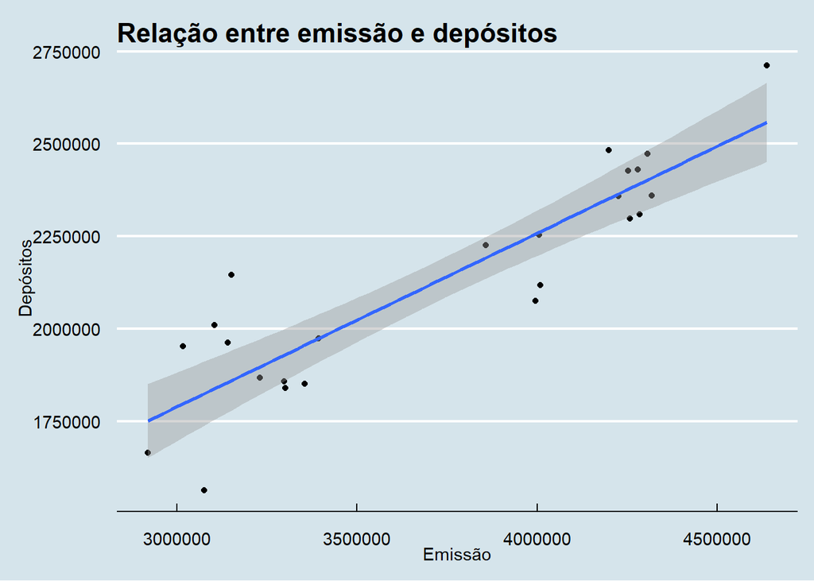

O gráfico mostra que a relação entre o papel-moeda emitido e os depósitos é linear. À medida que a emissão de moeda aumenta, os depósitos também aumentam.

A correlação igual a 0,90 indica que o efeito da emissão de moeda sobre os depósitos é forte.

2. Teste se há relação linear (apenas). Só transcreva a tabela com os resultados dos testes para os coeficientes de regressão e analise-a.
3. Interprete os coeficientes de regressão, descrevendo os intervalos de variação dos coeficientes.

|  | Estimate | Std. Error | t value | Pr(>\|t\|) |
| --- | --- | --- | --- | --- |
| (Intercept) | 3.81e+05 | 1.86e+05 | 2.05 | 0.052 |
| x | 4.70e-01 | 4.90e-02 | 9.54 | 0.000 |

O valor-p maior do que 5%, na última coluna, referente ao intercepto indica que a equação de regressão é do tipo y = b*x .

As hipóteses são:

Ho (hipótese nula): a reta passa pela origem e a equação fica y = b*x

Ha (hipótese alternativa): a reta não passa pela origem e equação fica y = a + b*x

Nesse cenário, é preciso refazer a regressão, inserindo -1 dentro do modelo.

|  | Estimate | Std. Error | t value | Pr(>\|t\|) |
| --- | --- | --- | --- | --- |
| x | 0.569 | 0.007 | 76.2 | 0 |

A equação estimada é Depósitos = 0,57 * Emissão.

|  | 2.5 % | 97.5 % |
| --- | --- | --- |
| x | 0.554 | 0.585 |

O coeficiente angular igual a 0.57 indica o acréscimo médio dado aos depósitos quando a emissão de papel moeda aumenta em uma unidade, que pode ser qualquer valor no intervalo 0.55 e 0.58 com 95% de confiança.